# Исследование рынка заведений общественного питания Москвы.

Для привлечения инвесторов в проект нового небольшого кафе в Москве, особенностью которого будут роботы, обслуживающие посетителей, мы проведем исследование рынка заведений общественного питания Москвы. Цель исследования определить текущее положение дел на рынке, а также ответить на вопрос, сможет ли новое заведение оставаться популярным долгое время.

Исследование проводится на основе открытых данных о заведениях общественного питания в Москве.

```python
import pandas as pd
import matplotlib.pyplot as plt
import seaborn as sns
import numpy as np

from io import BytesIO
import requests

import warnings
warnings.filterwarnings('ignore')

plt.style.use('seaborn-deep')
```

## Обзор данных

**Таблица с данными о заведениях общественного питания Москвы**

```python
rest_data = pd.read_csv('/datasets/rest_data.csv')
rest_data.head(20)
```

|  | id | object_name | chain | object_type | address | number |
| --- | --- | --- | --- | --- | --- | --- |
| 0 | 151635 | СМЕТАНА | нет | кафе | город Москва, улица Егора Абакумова, дом 9 | 48 |
| 1 | 77874 | Родник | нет | кафе | город Москва, улица Талалихина, дом 2/1, корпус 1 | 35 |
| 2 | 24309 | Кафе «Академия» | нет | кафе | город Москва, Абельмановская улица, дом 6 | 95 |
| 3 | 21894 | ПИЦЦЕТОРИЯ | да | кафе | город Москва, Абрамцевская улица, дом 1 | 40 |
| 4 | 119365 | Кафе «Вишневая метель» | нет | кафе | город Москва, Абрамцевская улица, дом 9, корпус 1 | 50 |
| 5 | 27429 | СТОЛ. ПРИ ГОУ СОШ № 1051 | нет | столовая | город Москва, Абрамцевская улица, дом 15, корп... | 240 |
| 6 | 148815 | Брусника | да | кафе | город Москва, переулок Сивцев Вражек, дом 6/2 | 10 |
| 7 | 20957 | Буфет МТУСИ | нет | столовая | город Москва, Авиамоторная улица, дом 8, строе... | 90 |
| 8 | 20958 | КПФ СЕМЬЯ-1 | нет | столовая | город Москва, Авиамоторная улица, дом 8, строе... | 150 |
| 9 | 28858 | Столовая МТУСИ | нет | столовая | город Москва, Авиамоторная улица, дом 8, строе... | 120 |
| 10 | 148595 | Пекарня 24 | нет | закусочная | город Москва, Авиамоторная улица, дом 47 | 5 |
| 11 | 23394 | Гогиели | нет | кафе | город Москва, Авиамоторная улица, дом 49/1 | 24 |
| 12 | 28582 | ШКОЛА 735 | нет | столовая | город Москва, Авиамоторная улица, дом 51 | 140 |
| 13 | 22579 | Алло Пицца | да | кафе | город Москва, улица Авиаторов, дом 14 | 32 |
| 14 | 23670 | Гимназия 1542 | нет | столовая | город Москва, улица Авиаторов, дом 16 | 270 |
| 15 | 23663 | Школа 1011 | нет | столовая | город Москва, улица Авиаторов, дом 18 | 320 |
| 16 | 144107 | Суши Wok | да | предприятие быстрого обслуживания | город Москва, Азовская улица, дом 3 | 7 |
| 17 | 154654 | Донер Кебаб | нет | предприятие быстрого обслуживания | город Москва, Азовская улица, дом 4 | 2 |
| 18 | 58565 | Тануки | да | ресторан | город Москва, Большая Академическая улица, дом 65 | 160 |
| 19 | 153644 | Американская Лаборатория Десертов | нет | кафе | город Москва, Филипповский переулок, дом 15/5 | 20 |

```python
rest_data.info()
```

```
<class 'pandas.core.frame.DataFrame'>
RangeIndex: 15366 entries, 0 to 15365
Data columns (total 6 columns):
 #   Column       Non-Null Count  Dtype
---  ------       --------------  -----
 0   id           15366 non-null  int64
 1   object_name  15366 non-null  object
 2   chain        15366 non-null  object
 3   object_type  15366 non-null  object
 4   address      15366 non-null  object
 5   number       15366 non-null  int64
dtypes: int64(2), object(4)
memory usage: 720.4+ KB
```

Таблица содержит следующие данные:

- столбец `id` — идентификатор объекта;
- столбец `object_name` — название объекта общественного питания;
- столбец `chain` — сетевой ресторан;
- столбец `object_type` — тип объекта общественного питания;
- столбец `address` — адрес;
- столбец `number` — количество посадочных мест.

  В таблице 15366 строк, незаполненных значений нет. Типы данных столбцов соответствуют хранящимсяя в них сведениям.

  В записи названий заведений нет единого принципа. Используются разные регистры, где-то имеются кавычки и сокращения, где-то нет, также в каких-то ячейках записан по-мимо названия еще и тип заведения. Можно предположить, что данный столбец содержит множество неявных дубликатов. Единого принципа записи данных нет и в столбце с адресами заведений.

**Таблица с улицами и районами Москвы из внешнего источника**

```python
spreadsheet_id = '11Yn1pFgqzclJ90FY-0V0JseT2WH15PCTcjZW67AkU-Q'
file_name = 'https://docs.google.com/spreadsheets/d/{}/export?format=csv'.format(spreadsheet_id)
r = requests.get(file_name)
moscow_streets = pd.read_csv(BytesIO(r.content))
```

```python
moscow_streets.head()
```

|  | streetname | areaid | okrug | area |
| --- | --- | --- | --- | --- |
| 0 | Выставочный переулок | 17 | ЦАО | Пресненский район |
| 1 | улица Гашека | 17 | ЦАО | Пресненский район |
| 2 | Большая Никитская улица | 17 | ЦАО | Пресненский район |
| 3 | Глубокий переулок | 17 | ЦАО | Пресненский район |
| 4 | Большой Гнездниковский переулок | 17 | ЦАО | Пресненский район |

## Предобработка данных

Проверим на наличие полных дубликатов строк

```python
if rest_data.duplicated().sum()== 0:
    print('Полных дубликатов строк нет')
else:
    print('Количество полных дубликатов строк', rest_data.duplicated().sum())
```

```
Полных дубликатов строк нет
```

Проверим данные по столбцам

**Столбец `id`**

```python
if rest_data['id'].duplicated().sum()== 0:
    print('Столбец не содержит дубликатов')
else:
    print('Количество дубликатов значений в столбце', rest_data.duplicated().sum())
```

```
Столбец не содержит дубликатов
```

**Столбец `chain`**

Посмотрим на уникальные значения этого столбца

```python
rest_data['chain'].unique()
```

```
array(['нет', 'да'], dtype=object)
```

Столбец заполнен корректно

**Столбец `object_name`**

Приведем все записи с названиями заведений к единому регистру

```python
print('Количество уникальных значений в столбце `object_name`перед обработкой', rest_data['object_name'].nunique())
rest_data['object_name'] = rest_data['object_name'].str.lower()
print('Количество уникальных значений в столбце `object_name` после обработки', rest_data['object_name'].nunique())
```

```
Количество уникальных значений в столбце `object_name`перед обработкой 10393
Количество уникальных значений в столбце `object_name` после обработки 9924
```

Уберем из названий заведений кавычки и слова дублирующие их тип (кафе, ресторан и т.д.)

Для этого напишем функцию и применим ее

```python
print('Количество уникальных значений в столбце `object_name` перед обработкой', rest_data['object_name'].nunique())

# дополнительно заменим "-" на пробел
rest_data['object_name'] = rest_data['object_name'].str.replace('-', ' ')

# Функция для удаления типа заведения из названия
def replace_object_name(wrong_names):
        for wrong_name in wrong_names:
            rest_data['object_name'] = rest_data['object_name'].str.replace(wrong_name, '').str.strip()


# список слов, которые нужно удалить из значений в столбце
duplicates = ['«', '»', ',', 'кафе ','столовая ', 'закусочная ',
              ' предприятие быстрого обслуживания ', 'ресторан ',
              'кафетерий ', 'буфет ', 'бар ',
              'кофейня ', 'пиццерия ', 'пекарня ', 'кондитерская ',
              ' быстрого питания ', ' быстрого питания'
              'пбо ', ' пбо', ' кафе', ' бар', 'паб ', ' паб',
              ' столовая', ' закусочная',
              'предприятие быстрого обслуживания ', ' ресторан',
              ' кафетерий', ' буфет',' кофейня', ' пиццерия',
              ' пекарня', ' кондитерская', 'быстрого питания '

             ]

# вызов функции
replace_object_name(duplicates)


print('Количество уникальных значений в столбце `object_name` после обработки', rest_data['object_name'].nunique())
```

```
Количество уникальных значений в столбце `object_name` перед обработкой 9924
Количество уникальных значений в столбце `object_name` после обработки 9085
```

Посмотрим, не появились ли незаполненные значения в столбце после обработки

```python
rest_data['object_name'].isna().sum()
```

```
0
```

```python
rest_data.head(10)
```

|  | id | object_name | chain | object_type | address | number |
| --- | --- | --- | --- | --- | --- | --- |
| 0 | 151635 | сметана | нет | кафе | город Москва, улица Егора Абакумова, дом 9 | 48 |
| 1 | 77874 | родник | нет | кафе | город Москва, улица Талалихина, дом 2/1, корпус 1 | 35 |
| 2 | 24309 | академия | нет | кафе | город Москва, Абельмановская улица, дом 6 | 95 |
| 3 | 21894 | пиццетория | да | кафе | город Москва, Абрамцевская улица, дом 1 | 40 |
| 4 | 119365 | вишневая метель | нет | кафе | город Москва, Абрамцевская улица, дом 9, корпус 1 | 50 |
| 5 | 27429 | стол. при гоу сош № 1051 | нет | столовая | город Москва, Абрамцевская улица, дом 15, корп... | 240 |
| 6 | 148815 | брусника | да | кафе | город Москва, переулок Сивцев Вражек, дом 6/2 | 10 |
| 7 | 20957 | мтуси | нет | столовая | город Москва, Авиамоторная улица, дом 8, строе... | 90 |
| 8 | 20958 | кпф семья 1 | нет | столовая | город Москва, Авиамоторная улица, дом 8, строе... | 150 |
| 9 | 28858 | мтуси | нет | столовая | город Москва, Авиамоторная улица, дом 8, строе... | 120 |

Посмотрим на названия сетей.

```python
chain =(
    rest_data.query('chain == "да"')
    .groupby('object_name')
    .agg({'id': 'count'})
    .reset_index()
    .sort_values(by='id', ascending=False)
)
print('Всего сетевых заведений', chain['id'].sum())
print('Всего сетей c одним заведением', chain.query('id == 1')['id'].sum())
chain.head(60)
```

```
Всего сетевых заведений 2968
Всего сетей c одним заведением 214
```

|  | object_name | id |
| --- | --- | --- |
| 402 | шоколадница | 183 |
| 25 | kfc | 176 |
| 224 | макдоналдс | 171 |
| 104 | бургер кинг | 152 |
| 358 | теремок | 108 |
| 155 | домино'с пицца | 98 |
| 205 | крошка картошка | 95 |
| 343 | суши wok | 75 |
| 234 | милти | 75 |
| 262 | папа джонс | 65 |
| 153 | додо пицца | 54 |
| 390 | чайхона №1 | 49 |
| 408 | якитория | 48 |
| 192 | кофе с собой | 47 |
| 354 | тануки | 47 |
| 380 | хинкальная | 43 |
| 195 | кофе хаус | 42 |
| 52 | subway | 37 |
| 168 | иль патио | 34 |
| 384 | хлеб насущный | 33 |
| 46 | starbucks | 32 |
| 244 | му му | 32 |
| 296 | прайм стар | 28 |
| 332 | старбакс | 27 |
| 248 | мята lounge | 25 |
| 79 | андерсон | 25 |
| 9 | cofix | 25 |
| 284 | пицца хат | 24 |
| 207 | кулинарная лавка братьев караваевых | 19 |
| 314 | сабвей | 19 |
| 206 | кружка | 19 |
| 294 | прайм | 17 |
| 280 | пицца паоло | 17 |
| 350 | сушишоп | 17 |
| 120 | волконский | 17 |
| 406 | штолле | 17 |
| 198 | кофемания | 16 |
| 75 | алло пицца | 15 |
| 335 | стардогs | 15 |
| 88 | баскин роббинс | 14 |
| 346 | суши сет | 14 |
| 344 | суши вок | 14 |
| 151 | джон джоли | 13 |
| 187 | корчма тарас бульба | 12 |
| 110 | ваби саби | 12 |
| 112 | вареничная №1 | 11 |
| 364 | то да сё | 11 |
| 131 | грабли | 10 |
| 371 | урюк | 10 |
| 253 | нияма | 9 |
| 119 | воккер | 9 |
| 170 | иль патио планета суши | 9 |
| 376 | французская выпечка | 9 |
| 285 | пицца экспресс | 9 |
| 100 | братья караваевы | 9 |
| 12 | costa coffee | 8 |
| 103 | брусника | 8 |
| 305 | пронто | 8 |
| 312 | ростикс kfc | 8 |
| 185 | колбасофф | 8 |

Посмотрим на сетевые заведения, выбранные случайным образом.

```python
chain.sample(30)
```

|  | object_name | id |
| --- | --- | --- |
| 268 | перекресток | 1 |
| 246 | мясоroob | 2 |
| 260 | павлин мавлин чайхона №1 | 1 |
| 100 | братья караваевы | 9 |
| 109 | вlack burger чайхона №1 | 1 |
| 274 | пироги штолле | 1 |
| 120 | волконский | 17 |
| 226 | макс бреннер | 1 |
| 227 | марукамэ | 1 |
| 390 | чайхона №1 | 49 |
| 236 | мимино хинкальная | 1 |
| 39 | panda express | 1 |
| 183 | квартира 44 | 2 |
| 389 | чайхана урюк | 1 |
| 276 | пиу дель чибо | 1 |
| 51 | starlite diner | 2 |
| 161 | жан жак | 5 |
| 243 | мск московская сеть кальянных на шаболовке | 1 |
| 306 | простые вещи | 3 |
| 365 | торнадо | 1 |
| 21 | grand урюк | 1 |
| 319 | сварня | 3 |
| 233 | милано пицца | 1 |
| 63 | upside down | 1 |
| 121 | восточный базар | 2 |
| 398 | шашлык машлык | 1 |
| 286 | пиццетория | 2 |
| 400 | шикари иль патио | 1 |
| 263 | папа джонс пицца | 1 |
| 191 | кофе бин | 3 |

Как видно одни и те же названия записаны по-разному (например "суши вок" и "суши wok"), часто в названиях по-мимо наименования сети добавлена улица или какая-либо характеристика заведения.

Уменьшим количество таких наименований сетей.

Первым шагом составим список из 60 наиболее часто встречающихся названий сетей. Сопоставим названия из этого списка с наименованиями заведений в таблице и, если они содержат совпадающие слова, заменим на часто встречающееся.

```python
chain_big = chain['object_name'].head(60)
```

```python
print(
    'Количество уникальных значений в столбце `object_name` перед обработкой',
    rest_data['object_name'].nunique()
)
for i in chain_big:
    for name in rest_data['object_name'].unique():
        if i in name:
            rest_data.loc[rest_data['object_name'] == name, 'object_name'] = i
print(
    'Количество уникальных значений в столбце `object_name` после обработки',
    rest_data['object_name'].nunique()
)
```

```
Количество уникальных значений в столбце `object_name` перед обработкой 9085
Количество уникальных значений в столбце `object_name` после обработки 8940
```

Теперь уберем названия дубликаты среди 60 наиболее часто встрячающихся названий сетей.

```python
rest_data.loc[rest_data['object_name'] == 'subway', ['object_name']] = 'сабвей'
rest_data.loc[rest_data['object_name'] == 'кулинарная лавка братьев караваевых', ['object_name']] = 'братья караваевы'
rest_data.loc[rest_data['object_name'] == 'starbucks', ['object_name']] = 'старбакс'
rest_data.loc[rest_data['object_name'] == 'суши wok', ['object_name']] = 'суши вок'
```

Проверим результат

```python
(
    rest_data.query('chain == "да"')
    .groupby('object_name')
    .agg({'id': 'count'})
    .reset_index()
    .sort_values(by='id', ascending=False)
    .head(10)
)
```

|  | object_name | id |
| --- | --- | --- |
| 22 | kfc | 188 |
| 312 | шоколадница | 185 |
| 180 | макдоналдс | 173 |
| 83 | бургер кинг | 159 |
| 279 | теремок | 111 |
| 127 | домино'с пицца | 99 |
| 166 | крошка картошка | 96 |
| 265 | суши вок | 90 |
| 190 | милти | 81 |
| 258 | старбакс | 71 |

Посмотрим на сети с 1 заведением.

```python
(
    rest_data.query('chain == "да"')
    .groupby('object_name')
    .agg({'id': 'count'})
    .reset_index()
    .query('id == 1')
    .sort_values(by='object_name')

)
```

|  | object_name | id |
| --- | --- | --- |
| 0 | beverly hills diner | 1 |
| 1 | bierloga | 1 |
| 2 | black & white | 1 |
| 4 | boobo | 1 |
| 5 | bubbleology | 1 |
| ... | ... | ... |
| 310 | шварцвальд | 1 |
| 313 | штирбирлиц | 1 |
| 315 | югос | 1 |
| 317 | ямми микс | 1 |
| 319 | японской кухни маки маки | 1 |

139 rows × 2 columns

Всего осталось 139 названий сетей с 1 заведением (около 5% от всех сетевых заведений). Среди них могут быть как сети, реально имеющие по 1 заведению в Москве, так и заведения с некорректно записанным названием, относящиеся к более крупным сетям. Поэтому нет оснований сделать эти заведения несетвым.

Проверим, сколько в итоге осталось уникальных названий заведений и сетей.

```python
print(
    'Количество уникальных значений в столбце `object_name` после обработки',
    rest_data['object_name'].nunique()
)
```

```
Количество уникальных значений в столбце `object_name` после обработки 8936
```

**Столбец `object_type`**

Посмотрим на его уникальные значения

```python
rest_data['object_type'].unique()
```

```
array(['кафе', 'столовая', 'закусочная',
       'предприятие быстрого обслуживания', 'ресторан', 'кафетерий',
       'буфет', 'бар', 'магазин (отдел кулинарии)'], dtype=object)
```

Неявных дубликатов нет.

**Столбец `address`**

Для поиска неявных дубликатов проверим, нет ли по одному адресу нескольких заведений с одинаковым названием.

```python
data_ad=(
    rest_data.groupby('address')
    .agg({'id': 'count', 'object_name': 'nunique'})
    .reset_index()
    .query('id > object_name')['address']
)
data_ad
```

```
174          город Москва, 1-я Останкинская улица, дом 55
244     город Москва, 19-й километр Московской Кольцев...
304     город Москва, 2-я Бауманская улица, дом 5, стр...
305     город Москва, 2-я Бауманская улица, дом 5, стр...
620     город Москва, Авиамоторная улица, дом 8, строе...
                              ...
8833    город Москва, улица Сущёвский Вал, дом 5, стро...
8874           город Москва, улица Трофимова, владение 36
8893                город Москва, улица Удальцова, дом 21
8902    город Москва, улица Улофа Пальме, дом 5, строе...
8967            город Москва, улица Черняховского, дом 4А
Name: address, Length: 153, dtype: object
```

У нас имеется 153 адреса зданий, в которых расположены 2 и более заведения с одинаковым названиями Посмотрим на эти заведения, сравним их по количеству посадочных мест и определим те, в которых совпадает адрес, название и количество посадочных мест

```python
rest_dubl =(
    rest_data.loc[rest_data['address'].isin(data_ad)]
    .groupby(['address', 'object_name', 'number']).agg({'number':'count'})
    .query('number > 1')
)

print('Всего возможных дубликатов', (rest_dubl['number'].sum()- rest_dubl['number'].count()))
rest_dubl.head(40)
```

```
Всего возможных дубликатов 96
```

| address | object_name | number | number |
| --- | --- | --- | --- |
| город Москва, 1-я Останкинская улица, дом 55 | кафе | 5 | 3 |
|  |  | 10 | 2 |
|  |  | 20 | 2 |
| город Москва, 2-я Бауманская улица, дом 5, строение 1 | комбинат питания мгту им.н.э.баумана | 16 | 2 |
|  |  | 100 | 2 |
| город Москва, Алтуфьевское шоссе, дом 70, корпус 1 | кофе с собой | 0 | 2 |
|  | пекарня | 0 | 2 |
| город Москва, Багратионовский проезд, дом 7, корпус 1 | lift | 20 | 2 |
| город Москва, Багратионовский проезд, дом 7, корпус 3 | lift | 10 | 2 |
| город Москва, Беловежская улица, дом 67 | гбоу города москвы № 384 | 100 | 2 |
| город Москва, Бескудниковский бульвар, дом 12 | шаурма | 0 | 2 |
| город Москва, Большая Семёновская улица, дом 16 | кафе | 5 | 3 |
| город Москва, Большая Тульская улица, дом 2 | осетинские пироги | 0 | 2 |
| город Москва, Большая Черкизовская улица, дом 125 | пунк питания | 0 | 2 |
|  |  | 2 | 2 |
|  | пункт питания | 0 | 2 |
| город Москва, Большой Староданиловский переулок, дом 5 | гостиница даниловская | 20 | 2 |
| город Москва, Зоологическая улица, дом 26А | буфет | 20 | 2 |
| город Москва, Каширское шоссе, владение 25Б | кафе | 10 | 2 |
| город Москва, Кировоградская улица, владение 15А | старый баку | 120 | 2 |
| город Москва, Кировоградская улица, дом 13А | макдоналдс | 0 | 2 |
| город Москва, Комсомольская площадь, дом 6, сооружение 1 | fresh bar | 0 | 2 |
| город Москва, Краснопресненская набережная, дом 14, сооружение 1 | экспомил | 70 | 2 |
| город Москва, Ленинградский проспект, дом 64 | мади | 40 | 2 |
| город Москва, Ленинский проспект, дом 68/10 | иль патио | 88 | 2 |
| город Москва, Люблинская улица, дом 112, строение 3 | закусочная | 0 | 5 |
|  | кафе | 0 | 2 |
|  |  | 10 | 3 |
|  | кафетерий | 0 | 2 |
| город Москва, Люблинская улица, дом 153 | павильон кукуруза | 2 | 5 |
| город Москва, Нахимовский проспект, дом 24, строение 1 | кафе | 15 | 2 |
| город Москва, Новозаводская улица, дом 12/11 | комбинат питания космос | 15 | 2 |
| город Москва, Новочеркасский бульвар, дом 57, корпус 1 | закусочная | 0 | 3 |
| город Москва, Огородный проезд, дом 7, строение 1 | при азс | 0 | 2 |
| город Москва, Ореховый бульвар, дом 14, корпус 3, строение 4 | кафетерий | 3 | 2 |
|  | шаурма | 0 | 2 |
| город Москва, Ореховый бульвар, дом 22А | при кинотеатре | 0 | 2 |
| город Москва, Ореховый бульвар, дом 24, корпус 1Г | буфет | 0 | 2 |
| город Москва, Павелецкая набережная, дом 2, строение 1 | кафе | 30 | 2 |
| город Москва, Профсоюзная улица, дом 61А | гришаев в.в | 0 | 2 |

Как видно, в основном это заведения без названия в крупных учреждениях или общественных объектах (например вокзал или университет). Наличие нескольких похохожих заведений в таких местах вполне вероятно, поэтому сложно определить их как дубликаты. Не будем удалять из данных строки с подобными заведениями. Даже если среди них есть дубликаты, их количество несущественно (максимум 96 из 15366 - 0,6%).

### Вывод

Мы проверили таблицу на наличие полных дубликатов строк, а также каждый столбец на явные и неявные дубликаты.

В результате предобработки количество уникальных названий сетей и заведений сократилось с 10393 до 8936 (почти на 14%). Вероятнее всего в таблице еще остались некорректно заполненные названия заведений, но их количество уже не так существенно и не повлияет на исследование.

Кроме того, мы определили наличие заведений с одинаковым названием, количеством посадочных мест и адресом. Большинство из них расположены в крупных учреждениях или общественных местах, где наличие нескольких одинаковых заведений общепита вполне возможно. Такие заведения тоже решили не удалять.

В целом данные готовы к дальнейшему исследованию.

## Анализ данных

### Виды объектов общественного питания

Посмотрим как распределены заведения общественного питания Москвы по видам.

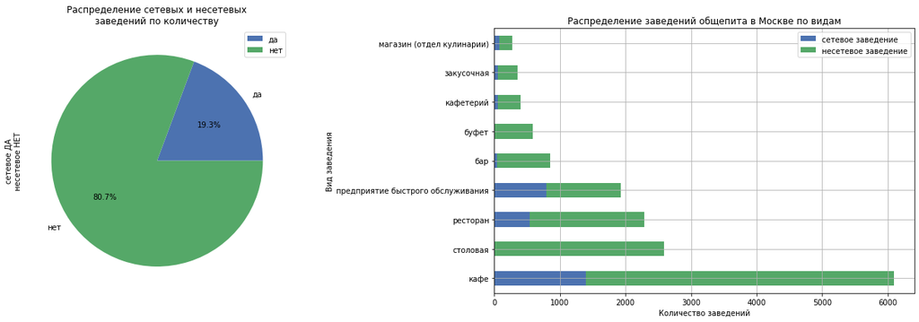

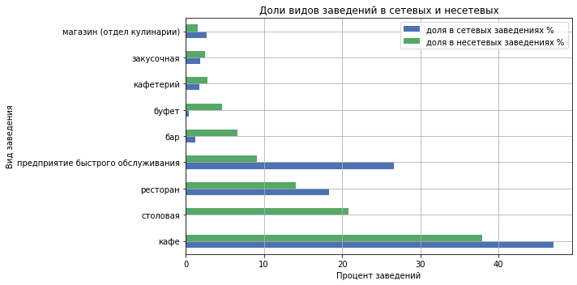

| вид заведения | сетевое | несетевое | всего заведений | доля в сетевых заведениях % | доля в несетевых заведениях % | доля всего % | доля сетевых в виде заведений % | доля несетевых в виде заведений % |
| --- | --- | --- | --- | --- | --- | --- | --- | --- |
| кафе | 1396 | 4703 | 6099 | 47.04 | 37.93 | 39.69 | 22.89 | 77.11 |
| столовая | 3 | 2584 | 2587 | 0.10 | 20.84 | 16.84 | 0.12 | 99.88 |
| ресторан | 544 | 1741 | 2285 | 18.33 | 14.04 | 14.87 | 23.81 | 76.19 |
| предприятие быстрого обслуживания | 791 | 1132 | 1923 | 26.65 | 9.13 | 12.51 | 41.13 | 58.87 |
| бар | 37 | 819 | 856 | 1.25 | 6.61 | 5.57 | 4.32 | 95.68 |
| буфет | 11 | 574 | 585 | 0.37 | 4.63 | 3.81 | 1.88 | 98.12 |
| кафетерий | 52 | 346 | 398 | 1.75 | 2.79 | 2.59 | 13.07 | 86.93 |
| закусочная | 56 | 304 | 360 | 1.89 | 2.45 | 2.34 | 15.56 | 84.44 |
| магазин (отдел кулинарии) | 78 | 195 | 273 | 2.63 | 1.57 | 1.78 | 28.57 | 71.43 |

```python
rest_type =(
    rest_data.pivot_table(index='object_type', columns='chain', values='id', aggfunc='count')


)
rest_type.index.name='вид заведения'
rest_type.columns = ['сетевое', 'несетевое']
rest_type['всего заведений'] = rest_type['сетевое'] + rest_type['несетевое']
rest_type = rest_type.sort_values(by='всего заведений', ascending=False)

rest_type['доля в сетевых заведениях %'] = (
    round((rest_type['сетевое'].div(rest_type['сетевое'].sum(), axis=0)) *100, 2)
)
rest_type['доля в несетевых заведениях %'] = (
    round((rest_type['несетевое'].div(rest_type['несетевое'].sum(), axis=0)) *100, 2)
)
rest_type['доля всего %'] = (
    round((rest_type['всего заведений'].div(rest_type['всего заведений'].sum(), axis=0)) *100, 2)
)
rest_type['доля сетевых в виде заведений %'] = (
    round((rest_type['сетевое'] / rest_type['всего заведений']) *100, 2)
)
rest_type['доля несетевых в виде заведений %'] = (
    round((rest_type['несетевое'] / rest_type['всего заведений']) *100, 2)
)



plt.subplots(figsize=(18,6))

ax1 = plt.subplot(1, 2, 2)

rest_type[['сетевое', 'несетевое']].plot(kind='barh', stacked=True, grid=True, ax=ax1)
plt.title('Распределение заведений общепита в Москве по видам')
plt.legend(['сетевое заведение', 'несетевое заведение'])
plt.ylabel('Вид заведения')
plt.xlabel('Количество заведений')


ax2 = plt.subplot(1, 2, 1)

(
    rest_data.groupby('chain')
    .agg({'id': 'count'})
    .plot(kind='pie', y='id', autopct='%1.1f%%', ax=ax2)
)
plt.title('Распределение сетевых и несетевых\nзаведений по количеству')
#plt.legend([['сетевые заведения', 'несетевые заведения']])
plt.ylabel('сетевое ДА\nнесетевое НЕТ')
#plt.xlabel('Процент заведений')
plt.tight_layout()
plt.show()

(
    rest_type[['доля в сетевых заведениях %', 'доля в несетевых заведениях %']]
    .plot(kind='barh', grid=True, figsize=(10,5))
)

plt.title('Доли видов заведений в сетевых и несетевых')
plt.legend(['доля в сетевых заведениях %', 'доля в несетевых заведениях %'])
plt.ylabel('Вид заведения')
plt.xlabel('Процент заведений')
plt.tight_layout()
plt.show()

rest_type
```

**Выводы.**

В общем количестве заведений общественного питания в Москве **преобладают несетевые** 81%.

**Основными видами заведений общепита** в Москве являются:

- Кафе - их доля почти 40% от всех заведений. Только 23% кафе являются сетевыми.
- Столовые на втором месте по количеству заведений - их почти 17% из всех заведений. Среди столовых правктически нет сетевых (0,12%).
- Рестораны занимают 14,9%. Среди них почти 24% сетевых.
- Предприятия быстрого обслуживания составляют 12,5 всех заведений общественного питания. Среди них самая высокая доля сетевых заведений - 41%.

Если рассматривать отдельно **сетевые заведения**, то для них характерно несколько иное распределение по видам:

- **Кафе** составляют 47% всех сетевых заведений.
- На втором месте **предприятия быстрого обслуживания** - 26,7%.
- На третьем месте **рестораны** - 18,3% всех сетевых заведений.

### Исследование сетей общественного питания по количеству заведений и посадочных мест.

Посмотрим какое количество заведений и посадочных мест в них характерно для сетей.

```python
chain_size =(
    rest_data.query('chain == "да"')
    .groupby('object_name')
    .agg({'id': 'count', 'number': 'median'})
)
chain_size.describe()
```

|  | id | number |
| --- | --- | --- |
| count | 322.000000 | 322.000000 |
| mean | 9.217391 | 56.822981 |
| std | 24.511348 | 51.038710 |
| min | 1.000000 | 0.000000 |
| 25% | 1.000000 | 20.000000 |
| 50% | 2.000000 | 45.000000 |
| 75% | 5.000000 | 80.375000 |
| max | 188.000000 | 306.000000 |

Как видно 75% сетей общественного питания в москве имеют 5 и менее заведений и до 80 посадочных мест. Самася крупная сеть имеет 188 заведений. Максимальное число посадочных мест в одном сетевом заведении 306.

Отнесем к сетям с многим количеством заведений сети с числом заведений больше или равно 5, а аведения с большим количеством посадочных мест определим как заведения с количеством мест больше или равно 20. Разделим сети на группы по этим признакам.

```python
chain_size['rest_num_group'] = 'Мало заведений'
chain_size.loc[chain_size['id'] >= 5, 'rest_num_group'] = 'Много заведений'
chain_size['seat_num_group'] = 'Мало мест'
chain_size.loc[chain_size['number'] >= 20, 'seat_num_group'] = 'Много мест'
chain_size['Группа'] = chain_size['rest_num_group'].astype(str) + '-' + chain_size['seat_num_group'].astype(str)
chain_size.head(10)
```

| object_name | id | number | rest_num_group | seat_num_group | Группа |
| --- | --- | --- | --- | --- | --- |
| beverly hills diner | 1 | 88.0 | Мало заведений | Много мест | Мало заведений-Много мест |
| bierloga | 1 | 75.0 | Мало заведений | Много мест | Мало заведений-Много мест |
| black & white | 1 | 40.0 | Мало заведений | Много мест | Мало заведений-Много мест |
| bocconcino | 3 | 68.0 | Мало заведений | Много мест | Мало заведений-Много мест |
| boobo | 1 | 46.0 | Мало заведений | Много мест | Мало заведений-Много мест |
| bubbleology | 1 | 6.0 | Мало заведений | Мало мест | Мало заведений-Мало мест |
| burger club | 3 | 20.0 | Мало заведений | Много мест | Мало заведений-Много мест |
| coffeeshop | 1 | 0.0 | Мало заведений | Мало мест | Мало заведений-Мало мест |
| coffeeshop company | 4 | 50.0 | Мало заведений | Много мест | Мало заведений-Много мест |
| cofix | 25 | 10.0 | Много заведений | Мало мест | Много заведений-Мало мест |

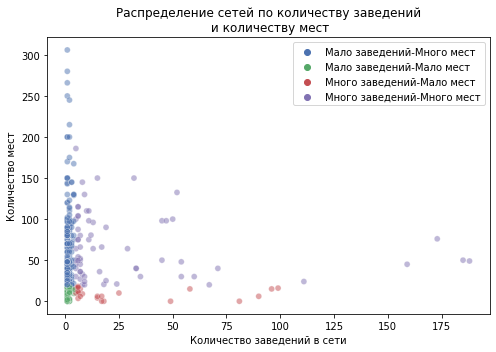

| Группа | Число сетей | Медианное число заведений | Медианное число посадочных мест |
| --- | --- | --- | --- |
| Мало заведений-Много мест | 179 | 1 | 62.5 |
| Много заведений-Много мест | 65 | 11 | 52.0 |
| Мало заведений-Мало мест | 53 | 1 | 10.0 |
| Много заведений-Мало мест | 25 | 8 | 10.0 |

```python
plt.figure(figsize=(7,5))
sns.scatterplot(data=chain_size, x='id', y='number', hue='Группа', alpha=0.5)
plt.title('Распределение сетей по количеству заведений\n и количеству мест')
plt.legend()
plt.ylabel('Количество мест')
plt.xlabel('Количество заведений в сети')
plt.tight_layout()
plt.show()

(
    chain_size.reset_index()
    .groupby('Группа')
    .agg({'object_name': 'nunique', 'id': 'median', 'number': 'median'})
    .rename(columns={'object_name': 'Число сетей', 'id': 'Медианное число заведений',
                    'number': 'Медианное число посадочных мест'})
    .sort_values(by='Число сетей', ascending=False)
)
```

**Вывод**

На диаграмме рассеивания видно, что большая часть сетей общественного питания имеет малое число заведений (1-3), Чаще всего в заведениях от 20 до 100 посадочных мест.

Можно сказать, что для сетей общественного питания в Москве более характерно малое число заведений с большим количеством посадочных мест.

### Исследование заведений по видам и числу посадочных мест.

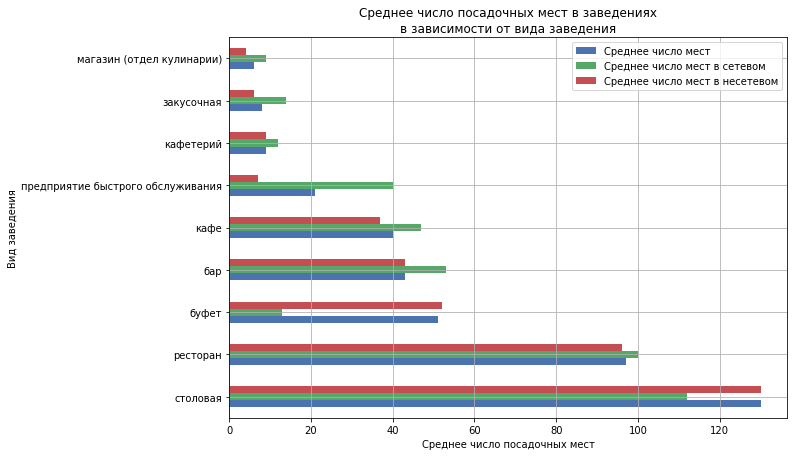

| Тип заведения | Среднее число мест | Среднее число мест в сетевом | Среднее число мест в несетевом |
| --- | --- | --- | --- |
| столовая | 130 | 112 | 130 |
| ресторан | 97 | 100 | 96 |
| буфет | 51 | 13 | 52 |
| бар | 43 | 53 | 43 |
| кафе | 40 | 47 | 37 |
| предприятие быстрого обслуживания | 21 | 40 | 7 |
| кафетерий | 9 | 12 | 9 |
| закусочная | 8 | 14 | 6 |
| магазин (отдел кулинарии) | 6 | 9 | 4 |

```python
seat_number_on_chain =(
    rest_data.pivot_table(index='object_type', columns='chain', values='number', aggfunc='mean')
    .round(0).astype(int)
    .reset_index()
)

seat_number =(
    rest_data.groupby('object_type')
    .agg({'number': 'mean'})
    .round(0).astype(int)
    .reset_index()
)

seat_number = seat_number.merge(seat_number_on_chain, on='object_type').sort_values(by='number', ascending=False)
seat_number.columns=['Тип заведения', 'Среднее число мест', 'Среднее число мест в сетевом', 'Среднее число мест в несетевом']
seat_number = seat_number.set_index('Тип заведения')

seat_number.plot(kind='barh', figsize=(10, 7), grid=True)
plt.title('Среднее число посадочных мест в заведениях\nв зависимости от вида заведения')
plt.legend()
plt.ylabel('Вид заведения')
plt.xlabel('Среднее число посадочных мест')
#plt.tight_layout()
plt.show()



seat_number
```

**Вывод**

Наибольшее число посадочных мест характерно для столовых (130), на втором месте по количеству мест рестораны (97), затем буфеты и бары (в среднем 51 и 43 посадочных мест соответственно). Меньше всего ожидаемо посадочных мест в магазинах (отделы кулинарии) - в среднем 6.

Для сетевых заведений характерно большее среднее число посадочных мест (за исключением столовых и буфетов - их практически нет в сетях, как мы уже выяснили). Особенно велика разница в среднем значении посадочных мест между сетевыми и несетевыми заведениями у предприятий быстрого обслуживания - в сетевых в среднем 40 посадочных мест, в несетевых всего 7 (на 82,5% меньше).

### Исследование объектов общественного питания в зависимости от места расположения.

Для удобства анализа выделим названия улиц, на которых расположены заведения в отдельный столбец

Напишем функцию для выделения улицы из столбца `address` и применим ее к таблице.

```python
def get_streetname(cell):
    for addr_part in cell.split(','):
        for s_type in ['аллея', 'бульвар', 'набережная', 'переулок', 'площадь', 'проезд', 'проспект', 'проулок', 'сквер',
                      'тупик', 'улица', 'шоссе']:
            if s_type in addr_part: return addr_part
    return cell.split(',')[1]

rest_data['streetname'] = rest_data['address'].apply(get_streetname)
rest_data['streetname'] = rest_data['streetname'].str.strip()

rest_data.info()
rest_data.head()
```

```
<class 'pandas.core.frame.DataFrame'>
RangeIndex: 15366 entries, 0 to 15365
Data columns (total 7 columns):
 #   Column       Non-Null Count  Dtype
---  ------       --------------  -----
 0   id           15366 non-null  int64
 1   object_name  15366 non-null  object
 2   chain        15366 non-null  object
 3   object_type  15366 non-null  object
 4   address      15366 non-null  object
 5   number       15366 non-null  int64
 6   streetname   15366 non-null  object
dtypes: int64(2), object(5)
memory usage: 840.5+ KB
```

|  | id | object_name | chain | object_type | address | number | streetname |
| --- | --- | --- | --- | --- | --- | --- | --- |
| 0 | 151635 | сметана | нет | кафе | город Москва, улица Егора Абакумова, дом 9 | 48 | улица Егора Абакумова |
| 1 | 77874 | родник | нет | кафе | город Москва, улица Талалихина, дом 2/1, корпус 1 | 35 | улица Талалихина |
| 2 | 24309 | академия | нет | кафе | город Москва, Абельмановская улица, дом 6 | 95 | Абельмановская улица |
| 3 | 21894 | пиццетория | да | кафе | город Москва, Абрамцевская улица, дом 1 | 40 | Абрамцевская улица |
| 4 | 119365 | вишневая метель | нет | кафе | город Москва, Абрамцевская улица, дом 9, корпус 1 | 50 | Абрамцевская улица |

Все значения в столбце `street` заполнены.

#### Улицы с самым большим числом объектов общественного питания.

Определим 10 улиц с самым большим количеством заведений.

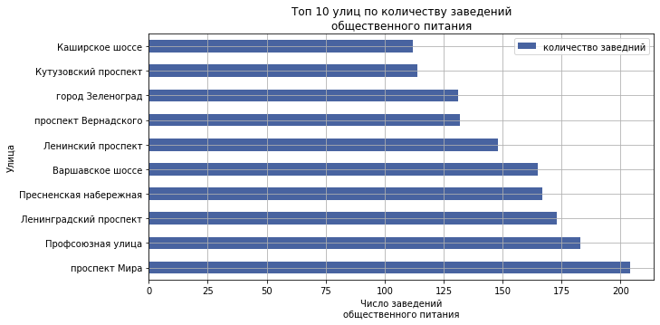

| улица | количество заведний |
| --- | --- |
| Каширское шоссе | 112 |
| Кутузовский проспект | 114 |
| город Зеленоград | 131 |
| проспект Вернадского | 132 |
| Ленинский проспект | 148 |
| Варшавское шоссе | 165 |
| Пресненская набережная | 167 |
| Ленинградский проспект | 173 |
| Профсоюзная улица | 183 |
| проспект Мира | 204 |

```python
top_street= (
    rest_data.groupby('streetname')
    .agg({'id': 'count'})
    .sort_values(by='id', ascending=False)
    .head(10)
)
top_street.index.name='улица'
top_street.columns=['количество заведний']
top_street.plot(kind='barh', figsize=(10, 5), grid=True, color='#4863A0')
plt.title('Топ 10 улиц по количеству заведений\nобщественного питания')
#plt.legend('')
plt.ylabel('Улица')
plt.xlabel('Число заведений\nобщественного питания')
#plt.tight_layout()
plt.show()

top_street.sort_values(by='количество заведний')
```

При помощи таблицы `moscow_streets`с перечнем улиц и районов Москвы, полученной из внешнего файла, определим в каких районах расположены эти улицы.

Отфильтруем таблицу по списку улиц с самым большим количеством заведений.

Проверим, что все 10 улиц попали в датафрейм.

```python
top_street_list = top_street.reset_index()['улица']

top_area = moscow_streets.query('streetname in @top_street_list')

if top_area['streetname'].nunique() == 10:
    print('Таблица составлена верно, включены все 10 улиц')
else:
    print('Есть ошибки')
```

```
Таблица составлена верно, включены все 10 улиц
```

```python
top_area.sort_values(by='streetname')
```

|  | streetname | areaid | okrug | area |
| --- | --- | --- | --- | --- |
| 3125 | Варшавское шоссе | 110 | ЮАО | Район Чертаново Южное |
| 4065 | Варшавское шоссе | 133 | ЮЗАО | Район Южное Бутово |
| 3117 | Варшавское шоссе | 108 | ЮАО | Район Чертаново Северное |
| 3105 | Варшавское шоссе | 109 | ЮАО | Район Чертаново Центральное |
| 3999 | Варшавское шоссе | 130 | ЮЗАО | Район Северное Бутово |
| 3305 | Варшавское шоссе | 102 | ЮАО | Район Нагатино-Садовники |
| 3349 | Варшавское шоссе | 104 | ЮАО | Нагорный район |
| 3241 | Варшавское шоссе | 99 | ЮАО | Донской район |
| 3292 | Каширское шоссе | 101 | ЮАО | Район Москворечье-Сабурово |
| 3308 | Каширское шоссе | 102 | ЮАО | Район Нагатино-Садовники |
| 3369 | Каширское шоссе | 106 | ЮАО | Район Орехово-Борисово Южное |
| 3392 | Каширское шоссе | 105 | ЮАО | Район Орехово-Борисово Северное |
| 1208 | Кутузовский проспект | 38 | ЗАО | Район Дорогомилово |
| 1280 | Кутузовский проспект | 49 | ЗАО | Район Фили-Давыдково |
| 1896 | Ленинградский проспект | 55 | САО | Район Беговой |
| 1992 | Ленинградский проспект | 69 | САО | Хорошевский район |
| 1857 | Ленинградский проспект | 54 | САО | Район Аэропорт |
| 2150 | Ленинградский проспект | 66 | САО | Район Сокол |
| 3886 | Ленинский проспект | 124 | ЮЗАО | Район Гагаринский |
| 3973 | Ленинский проспект | 128 | ЮЗАО | Ломоносовский район |
| 3986 | Ленинский проспект | 129 | ЮЗАО | Обручевский район |
| 1602 | Ленинский проспект | 47 | ЗАО | Район Тропарево-Никулино |
| 4021 | Ленинский проспект | 131 | ЮЗАО | Район Теплый Стан |
| 1504 | Ленинский проспект | 44 | ЗАО | Район Проспект Вернадского |
| 4163 | Ленинский проспект | 21 | ЦАО | Район Якиманка |
| 3260 | Ленинский проспект | 99 | ЮАО | Донской район |
| 72 | Пресненская набережная | 17 | ЦАО | Пресненский район |
| 3948 | Профсоюзная улица | 126 | ЮЗАО | Район Коньково |
| 4024 | Профсоюзная улица | 131 | ЮЗАО | Район Теплый Стан |
| 3845 | Профсоюзная улица | 123 | ЮЗАО | Академический район |
| 3867 | Профсоюзная улица | 132 | ЮЗАО | Район Черемушки |
| 3916 | Профсоюзная улица | 134 | ЮЗАО | Район Ясенево |
| 3996 | Профсоюзная улица | 129 | ЮЗАО | Обручевский район |
| 1801 | город Зеленоград | 53 | Зеленоград | Панфиловский район |
| 1757 | город Зеленоград | 52 | Зеленоград | Район Матушкино-Савелки |
| 1700 | город Зеленоград | 51 | Зеленоград | Район Крюково |
| 1501 | проспект Вернадского | 44 | ЗАО | Район Проспект Вернадского |
| 1510 | проспект Вернадского | 45 | ЗАО | Район Раменки |
| 1598 | проспект Вернадского | 47 | ЗАО | Район Тропарево-Никулино |
| 3878 | проспект Вернадского | 124 | ЮЗАО | Район Гагаринский |
| 3967 | проспект Вернадского | 128 | ЮЗАО | Ломоносовский район |
| 2644 | проспект Мира | 81 | СВАО | Район Ростокино |
| 2293 | проспект Мира | 70 | СВАО | Алексеевский район |
| 2390 | проспект Мира | 86 | СВАО | Ярославский Район |
| 2531 | проспект Мира | 78 | СВАО | Район Марьина роща |
| 2578 | проспект Мира | 79 | СВАО | Останкинский район |
| 2712 | проспект Мира | 82 | СВАО | Район Свиблово |
| 4334 | проспект Мира | 16 | ЦАО | Мещанский район |

Как видно практически все улицы проходят через несколько районов. Посчитаем сколько в среднем заведений приходится на один район по каждой улице.

Построим график.

```python
top_street_on_area =(
    pd.merge(top_street,
             top_area.groupby('streetname').agg({'area': 'nunique'})
             , left_index=True, right_index=True)
)
top_street_on_area.index.name='улица'
top_street_on_area.columns = ['число заведний', 'число районов']
top_street_on_area['среднее число заведений на район'] =(
    round(top_street_on_area['число заведний'] / top_street_on_area['число районов'], 0)
    .astype(int)

)

top_street_on_area =top_street_on_area.sort_values(by='среднее число заведений на район', ascending=False)
```

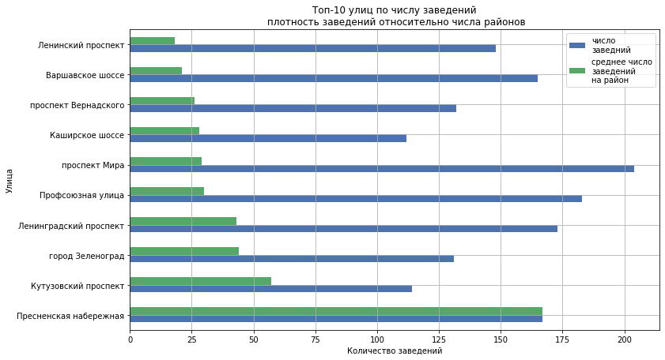

| улица | число заведний | число районов | среднее число заведений на район |
| --- | --- | --- | --- |
| Пресненская набережная | 167 | 1 | 167 |
| Кутузовский проспект | 114 | 2 | 57 |
| город Зеленоград | 131 | 3 | 44 |
| Ленинградский проспект | 173 | 4 | 43 |
| Профсоюзная улица | 183 | 6 | 30 |
| проспект Мира | 204 | 7 | 29 |
| Каширское шоссе | 112 | 4 | 28 |
| проспект Вернадского | 132 | 5 | 26 |
| Варшавское шоссе | 165 | 8 | 21 |
| Ленинский проспект | 148 | 8 | 18 |

```python
top_street_on_area[['число заведний','среднее число заведений на район']].plot(kind='barh', figsize=(12, 7), grid=True)
plt.title('Топ-10 улиц по числу заведений\n плотность заведений относительно числа районов')
plt.legend(['число\nзаведний', 'среднее число\nзаведений\nна район'])
plt.ylabel('Улица')
plt.xlabel('Количество заведений')
#plt.tight_layout()
plt.show()

top_street_on_area
```

**Вывод**

По числу заведений, рассположенных на одной улице лидирует Проспект Мира, на втором месте Профсоюзная улица.

Но все улицы разные по длине. Определив в каких районах они расположены мы посчитали среднее число заведений на район по каждой улице. Наиболее высокая плотность заведений на Пресненской набережной (167 на 1 район), на втором месте Кутузовский проспект (57 заведений на район), на третьем - Зеленоград (44 заведения на район). Самая низкая плотность заведений в топ-10 улиц по их количеству у Ленинского проспекта (18 заведений на район).

#### Улицы с наименьшим количеством заведений.

Определим улицы с одним объектом общественного питания.

```python
bottom_street= (
    rest_data.groupby('streetname')
    .agg({'id': 'count'})
    .query('id == 1')
)
bottom_street
```

| streetname | id |
| --- | --- |
| 1-й Балтийский переулок | 1 |
| 1-й Басманный переулок | 1 |
| 1-й Ботанический проезд | 1 |
| 1-й Вешняковский проезд | 1 |
| 1-й Голутвинский переулок | 1 |
| ... | ... |
| улица Шумилова | 1 |
| улица Шумкина | 1 |
| улица Щорса | 1 |
| улица Энгельса | 1 |
| шоссе Фрезер | 1 |

571 rows × 1 columns

Всего 571 улица с одним заведением. Определим в каких районах находятся эти улицы.

```python
bottom_street_list = bottom_street.reset_index()['streetname']

bottom_area = moscow_streets.query('streetname in @bottom_street_list')


print('Удалось определить район для', bottom_area['streetname'].nunique(), 'улиц')
```

```
Удалось определить район для 521 улиц
```

Посмотрим на улицы, по которым нет совпадений в справочнике

```python
bottom_area_list = bottom_area['streetname']

bottom_street.query('streetname not in @bottom_area_list')
```

| streetname | id |
| --- | --- |
| 1-й Заречный переулок | 1 |
| 1-я Ватутинская улица | 1 |
| 104-й километр Московской Кольцевой Автодороги | 1 |
| 2-я Барышевская улица | 1 |
| 26-й километр Московской Кольцевой Автодороги | 1 |
| 3-я Подрезковская улица | 1 |
| 30-й километр Московской Кольцевой Автодороги | 1 |
| 31-й километр Московской Кольцевой Автодороги | 1 |
| 34-й километр Московской Кольцевой Автодороги | 1 |
| 38-й километр Московской Кольцевой Автодороги | 1 |
| 39-й километр Калужского шоссе | 1 |
| 42-й километр Московской Кольцевой Автодороги | 1 |
| 56-й километр Московской Кольцевой Автодороги | 1 |
| 65-й километр Московской Кольцевой Автодороги | 1 |
| 67-й километр Московской Кольцевой Автодороги | 1 |
| 78-й километр Московской Кольцевой Автодороги | 1 |
| 80-й километр Московской Кольцевой Автодороги | 1 |
| Армейская улица | 1 |
| Большая Октябрьская улица | 1 |
| Институтский проезд | 1 |
| Молодежная улица | 1 |
| Новобутовский проезд | 1 |
| Новохорошёвский проезд | 1 |
| Пыжёвский переулок | 1 |
| Троицкий бульвар | 1 |
| Физическая улица | 1 |
| Фитарёвская улица | 1 |
| Цветочная улица | 1 |
| деревня Давыдково | 1 |
| деревня Дудкино | 1 |
| деревня Сенькино-Секерино | 1 |
| деревня Столбово | 1 |
| поселение Филимонковское | 1 |
| проектируемый проезд № 1980 | 1 |
| улица 1-й километр Объездной Дороги | 1 |
| улица Высоцкого | 1 |
| улица Горького | 1 |
| улица Дмитрия Рябинкина | 1 |
| улица Евгения Родионова | 1 |
| улица Капотня | 1 |
| улица Корнея Чуковского | 1 |
| улица Льва Яшина | 1 |
| улица Недорубова | 1 |
| улица Никитина | 1 |
| улица Потаповская Роща | 1 |
| улица Рассудовское Лесничество | 1 |
| улица Слобода | 1 |
| улица Старые Кузьминки | 1 |
| улица Школа-интернат | 1 |
| улица Энгельса | 1 |

Скорее всего названия не соответствуют справочнику по регистрам или порядку записи. Не будем искать соответствие для каждой улицы. Названия, включающие "Московсокой кольцевой автодороги" встречаются 12 раз. Посмотрим как они называются в справочнике и приведем к одному названию с вариантом в нем.

```python
moscow_streets[moscow_streets['streetname'].str.contains('80-й километр')]
```

|  | streetname | areaid | okrug | area |
| --- | --- | --- | --- | --- |
| 1953 | МКАД, 80-й километр | 60 | САО | Дмитровский район |

```python
bottom_street=bottom_street.reset_index()

bottom_street.loc[bottom_street['streetname'] .str.contains('Московской Кольцевой'), 'streetname'] = (
    'МКАД, ' + bottom_street['streetname'].astype(str)
)
bottom_street.loc[bottom_street['streetname'] .str.contains('Московской Кольцевой'), 'streetname'] = (
    bottom_street['streetname'].str.replace('Московской Кольцевой Автодороги', '').str.strip()
)
bottom_street[bottom_street['streetname'] .str.contains('километр')]
```

|  | streetname | id |
| --- | --- | --- |
| 39 | МКАД, 104-й километр | 1 |
| 79 | МКАД, 26-й километр | 1 |
| 95 | МКАД, 30-й километр | 1 |
| 96 | МКАД, 31-й километр | 1 |
| 97 | МКАД, 34-й километр | 1 |
| 98 | МКАД, 38-й километр | 1 |
| 99 | 39-й километр Калужского шоссе | 1 |
| 106 | МКАД, 42-й километр | 1 |
| 111 | МКАД, 56-й километр | 1 |
| 116 | МКАД, 65-й километр | 1 |
| 117 | МКАД, 67-й километр | 1 |
| 121 | МКАД, 78-й километр | 1 |
| 124 | МКАД, 80-й километр | 1 |
| 469 | улица 1-й километр Объездной Дороги | 1 |

Повторим поиск улиц в справочнике

```python
bottom_street_list = bottom_street['streetname']

bottom_area = moscow_streets.query('streetname in @bottom_street_list')


print('Удалось определить район для', bottom_area['streetname'].nunique(), 'улиц')
print('Улицы с одним заведенем проходят через', bottom_area['area'].nunique(), 'района')
```

```
Удалось определить район для 533 улиц
Улицы с одним заведенем проходят через 103 района
```

Определим районы, через которые проходит больше всего улиц с 1 заведением.

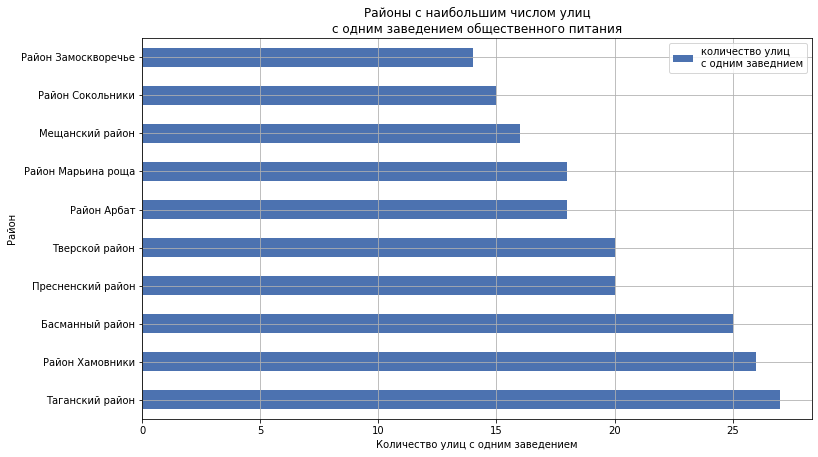

| Район | Число улиц с одним заведением |
| --- | --- |
| Таганский район | 27 |
| Район Хамовники | 26 |
| Басманный район | 25 |
| Пресненский район | 20 |
| Тверской район | 20 |
| Район Арбат | 18 |
| Район Марьина роща | 18 |
| Мещанский район | 16 |
| Район Сокольники | 15 |
| Район Замоскворечье | 14 |

```python
bottom_street_on_area = (
    pd.merge(bottom_street,
             bottom_area
             , on='streetname', how='left')
    .dropna()
    .groupby('area')
    .agg({'streetname': 'nunique'})
    .sort_values(by='streetname', ascending=False)
)
bottom_street_on_area.index.name = 'Район'
bottom_street_on_area.columns = ['Число улиц с одним заведением']
(
    bottom_street_on_area.head(10)
    .plot(kind='barh', figsize=(12, 7), grid=True)
)
plt.title('Районы с наибольшим числом улиц\nс одним заведением общественного питания')
plt.legend(['количество улиц\nс одним заведнием'])
plt.ylabel('Район')
plt.xlabel('Количество улиц с одним заведением')
#plt.tight_layout()
plt.show()



bottom_street_on_area.head(10)
```

**Вывод**

Большое количество улиц только с одним заведением общественного питания проходит в основном через центральные районы Москвы, где много исторической застройки и небольших по протяженности улочек.

### Распределение посадочных мест для улиц с большим количеством объектов общественного питания.

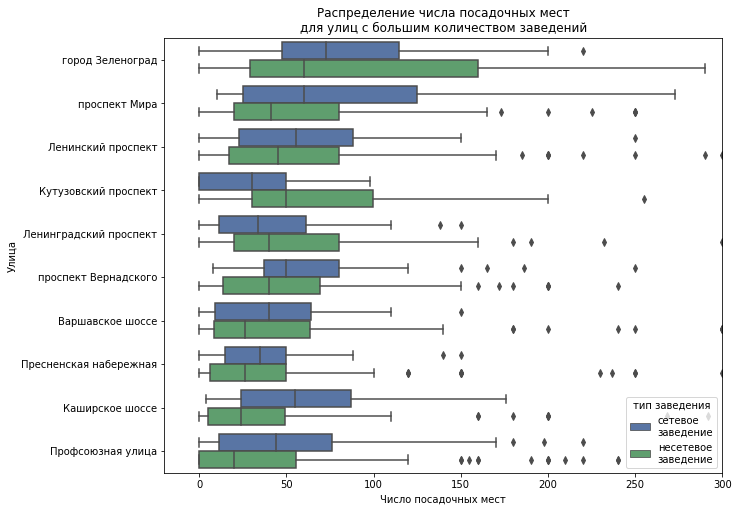

| Улица | медиана посадочных мест сетевое | медиана посадочных мест несетевое | медиана посадочных мест общая |
| --- | --- | --- | --- |
| город Зеленоград | 73 | 60 | 60 |
| проспект Мира | 60 | 41 | 46 |
| Ленинский проспект | 55 | 45 | 45 |
| Кутузовский проспект | 30 | 50 | 40 |
| Ленинградский проспект | 34 | 40 | 40 |
| проспект Вернадского | 50 | 40 | 40 |
| Варшавское шоссе | 40 | 26 | 30 |
| Пресненская набережная | 35 | 26 | 30 |
| Каширское шоссе | 55 | 24 | 25 |
| Профсоюзная улица | 44 | 20 | 24 |

```python
plt.figure(figsize=(10,8))
ax =(
    sns.boxplot(x='number', y='streetname', hue='chain',
               data=rest_data.query('streetname in @top_street_list'),
                order=['город Зеленоград', 'проспект Мира', 'Ленинский проспект',
                      'Кутузовский проспект', 'Ленинградский проспект', 'проспект Вернадского',
                      'Варшавское шоссе', 'Пресненская набережная', 'Каширское шоссе', 'Профсоюзная улица']
               )
)
ax.set_xlim(-20, 300)
plt.title('Распределение числа посадочных мест\nдля улиц с большим количеством заведений')

new1_legend_label = 'сетевое\nзаведение'
new2_legend_label = 'несетевое\nзаведение'
ax.legend(title="тип заведения")
ax.legend_.texts[0].set_text(new1_legend_label)
ax.legend_.texts[1].set_text(new2_legend_label)

ax.set_ylabel('Улица')
ax.set_xlabel('Число посадочных мест')

plt.show()

seat_top_street_on_chain = (
    pd.merge(
        rest_data.query('streetname in @top_street_list')
        .pivot_table(index='streetname', columns='chain', values='number', aggfunc='median'),
        rest_data.query('streetname in @top_street_list')
        .groupby('streetname').agg({'number': 'median'}),
        left_index=True, right_index=True
    )
    .astype(int)
    .sort_values(by='number', ascending=False)
)
seat_top_street_on_chain.index.name='Улица'
seat_top_street_on_chain.columns=['медиана посадочных мест сетевое',
                                  'медиана посадочных мест несетевое',
                                  'медиана посадочных мест общая']
seat_top_street_on_chain
```

**Вывод**

В целом для этих улиц, также, характерно, большее количество посадочных мест в сетевых заведениях (за исключением Ленинградского и Кутузовского проспектов).

Самые высокие медианные значения количества посадочных мест в Зеленограде. Здесь также самый большой разброс этого показателя у несетевых заведений. Наверное, потому что это целый пригород с большим количеством различных учреждений, в которых имеются крупные столовые.

Медиана количества посадочных мест большинства несетевых заведений стремится к нижней границе, значит значений заведений с меньшим количеством посадочных мест больше.

Кроме Зеленограда несетевые заведения с болшим количеством посадочных мест преобладают на Кутузовском и Ленинском проспектах.

Сетевые заведения с наибольшим количеством посадочных мест расположены на Проспекте Мира, Ленинском проспекте и Каширском шоссе. На проспекте Мира самый большой разброс значений количества посадочных мест у сетевых заведений.

Самые маленькие по количеству посадочных мест несетевые заведения расположены на Профсоюзной улице. А сетевые - на Кутузовском проспекте.

## Общий вывод.

В ходе исследования мы выяснили:

- В Москве преобладают несетевые заведения (почти 81%)
- Самый распространенный вид заведения общественного питания - это кафе (почти 40% всех заведений). Столовых - 17%, ресторанов - 15%.
- Самая высокая доля сетевых заведений среди предприятий быстрого обслуживания - 41% из них сетевые. Практически нет сетевых столовых - только 0,12% из всех столовых Москвы.

Почти половину всех сетевых заведений составляют кафе - 47%. На предприятия быстрого обслуживания приходится 27% сетевых заведений, и 18% сетевых заведений - это рестораны.

Самые распространенные сети общественного питания - это сети с небольшим количеством заведений (меньше 5) и большим количеством посадочных мест (более 20).

Улица с самым болшим количеством заведений - это проспект Мира, во многом из-за ее протяженности. По количеству заведений на район лидирует Пресненская набережная (167 заведений на этой улице в 1 районе), затем идет Кутузовский проспект - на 1 район в среднем приходится 57 заведений.

Если рассматривать улицы с наибольшим количеством заведений, то самые крупные (по количеству посадочных мест) преобладают в Зеленограде, на Проспекте Мира, Ленинсом проспекте. Заведения с меньшим количеством посадочных мест преобладают на Профсоюзной улице и Каширском шоссе.

**Рекомендации**

Для нового заведения можно рекомендовать тип кафе с количеством посадочных мест 30-35 (как один из самых распространенных в Москве). Такой формат можно будет сделать сетевым в случае успеха. В качестве района - Пресненскую набережную. Судя по плотности заведений там нет недостатка в посетителях. Кроме того, располеженный рядом Москва-Сити поддержит концепцию кафе - будущее и высокие технологии.

## Презентация

Презентация: https://drive.google.com/file/d/14L9V_eR3PKhaxQ1SS5__EUXrcllJxRFa/view?usp=sharing